# Ford GoBike System Data

## by Salomey Bezua

## Investigation Overview

> The aim of the presentation is to provide insights into the Ford GoBike System Data

## Dataset Overview

> The project uses Ford GoBike System data from the year 2018 (January to December). The dataset has 1736572 rows and 22 columns.

## (Visualization 1)

> The figure below depicts the distribution of bike rides during the day. Subcribers use the system more than the customers. There are two peaks representing the two busiest time(Rush hour) of the day. Subscribers usage increases at 8 a.m and 5p.m .

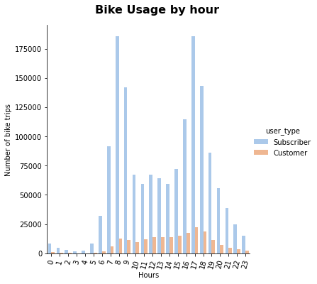

## (Visualization 2)

> It is observed that for subscribers, there is alot of demand from May to October and a decline in November through to March of the following year. This can be attributed to the Seasonal change. Similarly, this trend is observed for customers. The ratio of Males to Females is quite high for Subscibers as compared to the ratio for Customers

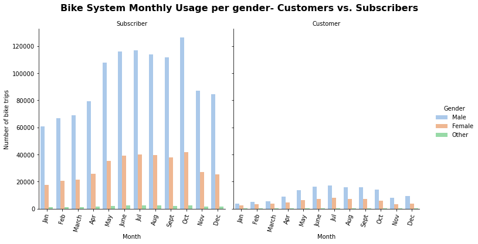

## (Visualization 3)

[figure not shown]